# Loan Data from Prosper Data Exploration

## by Shefali Mishra

## Investigation Overview

> In this investigation, I wanted to look at the loan amount taken by the different categories of borrowers. Also, the variation the Delinquent and Good borrowers had in various categories like BorrowerAPR , credit score etc.

## Dataset Overview

> This data set contains 113,937 loans with 81 variables on each loan, including loan amount, interest rate , current loan status, borrower income,employment status and credit history etc .

## 1. Correlation plot

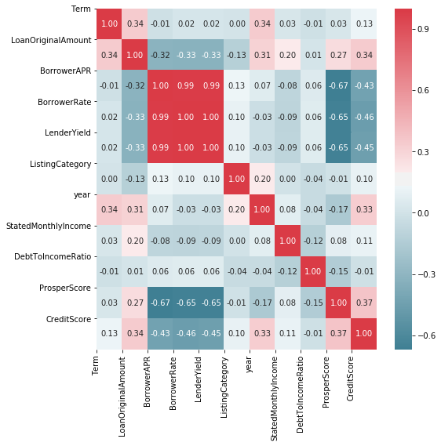

```python
corr = loann.corr()
fig, ax = plt.subplots(figsize=(8,8))
colormap = sb.diverging_palette(220, 10, as_cmap=True)
sb.heatmap(corr, cmap=colormap, annot=True, fmt=".2f")
plt.xticks(range(len(corr.columns)), corr.columns);
plt.yticks(range(len(corr.columns)), corr.columns);
plt.show()
```

From the above correlation plot, it can be concluded that as such there are no two variables that are strongly correlated , other than 'BorrowerAPR', 'BorrowerRate' and 'LenderYield' which are basically not significantly different from one another .  
These three are negatively correlated to ProsperScore , but again there is no strong correlation.

## 2. Prosper Score rating variation with Year and Loan Status

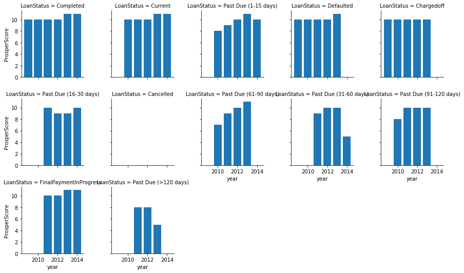

```python
g = sb.FacetGrid(data = loann, col = 'LoanStatus', height = 2.5,col_wrap=5,margin_titles = True);
g.map(plt.bar, 'year', 'ProsperScore');
```

I wanted to look at Chargedoff, Completed, Current and Defaulted LoanStatus. Chargedoff Loans have high ProsperScore , but they were not prominent after 2013, Same is the case for Defaulted LoanStatus. Also, it increased for Completed LoanStatus , perhaps reflecting the new strategy of Investors to select loans from the middle ProsperScore distribution.

## 3. Listing Category count variation with Borrower Type

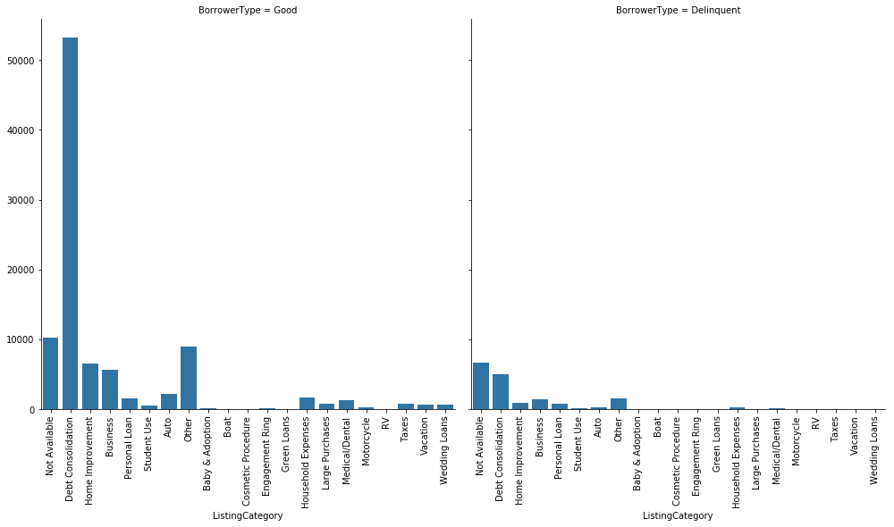

```python
label = ["Not Available","Debt Consolidation", "Home Improvement", "Business","Personal Loan", "Student Use", "Auto","Other", "Baby & Adoption", "Boat", "Cosmetic Procedure", "Engagement Ring", "Green Loans", "Household Expenses", "Large Purchases", "Medical/Dental", "Motorcycle", "RV", "Taxes", "Vacation", "Wedding Loans", "Other","Not Applicable"]
g = sb.FacetGrid(data = loann, col="BorrowerType" , height = 7, col_wrap=2, margin_titles = True );
g = g.map(sb.countplot, "ListingCategory");
g.set_xticklabels(labels=label, rotation=90);
```

The debt consolidation category is somewhat misleading as multiple categories could be lumped into one - which is exactly what it is by definition. But one thing we can take away from the high volume of borrowers requesting debt consolidation loans, is that, many borrowers have debt from multiple sources and is by far the most frequent category.